# World Cup Text Analysis

### Introduction

We wanted to see if we could be able to predict the winners of the world cup games based on text analysis of tweets a week prior to when the game was held. Whoever had the highest AFINN score, we predicted to be the winner. Here is an example of the data we collected:

|  | X | word | freq | score | sentiment | totalscore | posneg |
| --- | --- | --- | --- | --- | --- | --- | --- |
| 1 | 1 | colombia | 317 |  |  |  |  |
| 2 | 2 | worldcup | 301 |  |  |  |  |
| 3 | 3 | senegal | 154 |  |  |  |  |
| 4 | 4 | japan | 110 |  |  |  |  |
| 5 | 5 | belgium | 101 |  |  |  |  |
| 6 | 6 | sweden | 100 |  |  |  |  |
| 7 | 7 | switzerland | 100 |  |  |  |  |
| 8 | 8 | england | 99 |  |  |  |  |
| 9 | 9 | semi | 99 |  |  |  |  |
| 10 | 10 | one | 98 |  |  |  |  |

[output cut: 433 more lines]

### Analysis

Here are a couple of the things we were able to create with the Twitter Data. Here is an example of the different teams we analyzed:

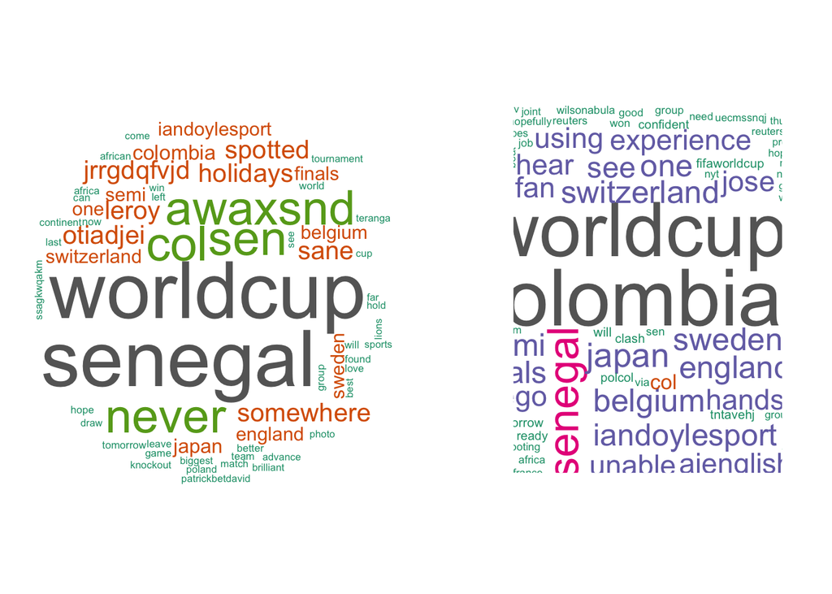

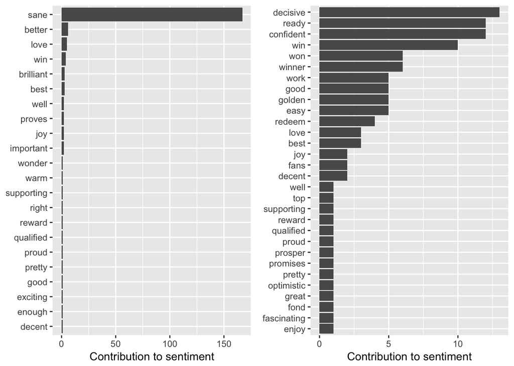

### Conclusion

Out of the 7 games that we gathered data for, we found that predicting the winner with just using the AFINN score was 3/7. So it isn’t super useful when trying to predict the winner of a Worldcup game. Some things that we could have done to make our results better is to look at the total positive word count to total word count. We could have also tried to look deeper in the context of how the words are being used, and use stop words to filter some of those out. Overall, we gained a better understanding in text analysis, and how to work in R while doing it.